# Homework 4

Each part of each question will be 2.5pts, there are 20 parts, so 50pts total.

## 1) Catamaran, revisited

Startup pet supply company Catamaran is trying to better understand the spending behavior of its customers. In particular, the company wants to find simple ways to predict how much customers will spend on Catamaran products from their purchases of just one such product: cat litter.

A (sadly, fictional) data set is stored in the file `catamaran.csv`, available from [here](https://pages.stat.wisc.edu/~bwu62/catamaran.csv). Download this file and save it in the same directory as your working directory (you can check this directory with `getwd()`). The data frame encoded in this file stores two columns:

1. The column titled `litter` is the amount of cat litter, in pounds, purchased by a customer in the past year (you’ll see in the data that Catamaran sells litter in three-pound increments; no, I don’t think that’s a realistic increment in which to sell cat littler. Fictional data is fun!).
2. The column titled `spending` is the amount of money, in dollars, that a customer has spent on Catamaran products (including cat litter) in the past year.

The following block of code loads the data in this file into a data frame `catamaran`.

```r
catamaran = read.csv('https://pages.stat.wisc.edu/~bwu62/catamaran.csv')
```

### Part a) inspecting the data

Create a scatterplot showing customer spending as a function of how much cat litter they bought. Do you see a linear trend? Based just on looking at the scatterplot, what do you estimate the slope to be (you will not be graded on the accuracy of this estimate– just give a best guess for fun to see how close it is to the estimated model!).

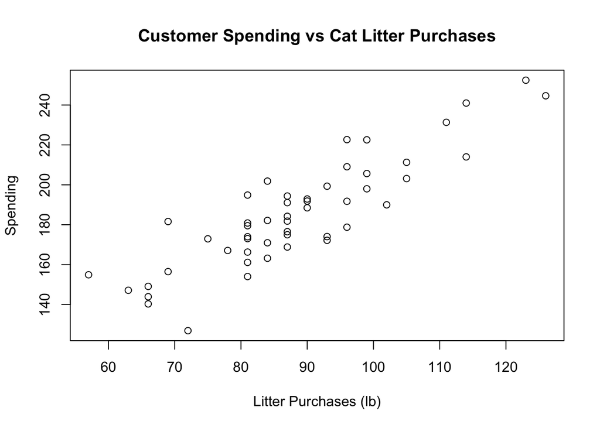

```r
plot(catamaran$litter, catamaran$spending, main = "Customer Spending vs Cat Litter Purchases", xlab = "Litter Purchases (lb)", ylab = "Spending")
```

Yes, I do see a linear trend. We can easily see that as litter purchases increase, total spending also increases in a linear fashion. However we must note that this does not imply causality! In terms of slope, spending has gone up to approximately 240 from 140 when litter purchases increased to 120 from 60, giving us a slope of approximately 100/60 = 1.6.

### Part b) fitting a model

Fit a linear model to the Catamaran data, regressing spending against the amount of litter purchased (and an intercept term).

Store the estimated intercept in a variable called `cat_intercept_hat`, and store the estimated coefficient of `litter` in a variable called `cat_slope_hat`. Don’t forget to use the `unname()` function to strip the labels off of these, ensuring that these two variables just store numbers.

```r
catamaran_lm = lm(spending ~ 1 + litter, data = catamaran)
cat_intercept_hat = unname(catamaran_lm$coefficients[1])
cat_intercept_hat
```

```
## [1] 44.35549
```

```r
cat_slope_hat = unname(catamaran_lm$coefficients[2])
cat_slope_hat
```

```
## [1] 1.596584
```

### Part c) interpreting the model

Based on these estimates, the purchase of one additional pound of cat litter per year is associated with how many more dollars per year spent on Catamaran products?

Based on the estimates, we see that the purchase of one additional pound of cat litter per year is associated with approximately 1.60 more dollars per year spent on Catamaran products.

As we mentioned above, Catamaran sells cat littler in three-pound units. Thus, a more natural question is: the purchase of one additional three-pound unit (i.e., three additional pounds) of cat littler is associated with an increase of how many more dollars per year spent on Catamaran products?

The more natural inspection would be that the purchase of one additional three-pound unit of cat litter is associated with an increase of approximately 4.79 more dollars spent on Catamaran products.

Perhaps a more sane increment in which to sell cat litter would be twenty-pound bags. Based on your estimated coefficients, an additional twenty pounds of cat litter purchased per year is associated with an increase of how many more dollars per year spent on Catamaran products?

Based on our estimated coefficients, an additional twenty pounds of cat litter purchased per year is associated with an increase of 31.93 more dollars per year spent on Catamaran products.

### Part d) generating a confidence interval

Of course, Catamaran’s data is noisy, so there is uncertainty in our estimate of the coefficients in our model.

Create a Q-Q plot to verify that the residuals of our model are approximately normal. Do you see anything unusual? You probably won’t– the observation errors in this fake data really are normal. Still, take a look just to be sure; it’s a good habit to always at least briefly check the appropriateness of your model.

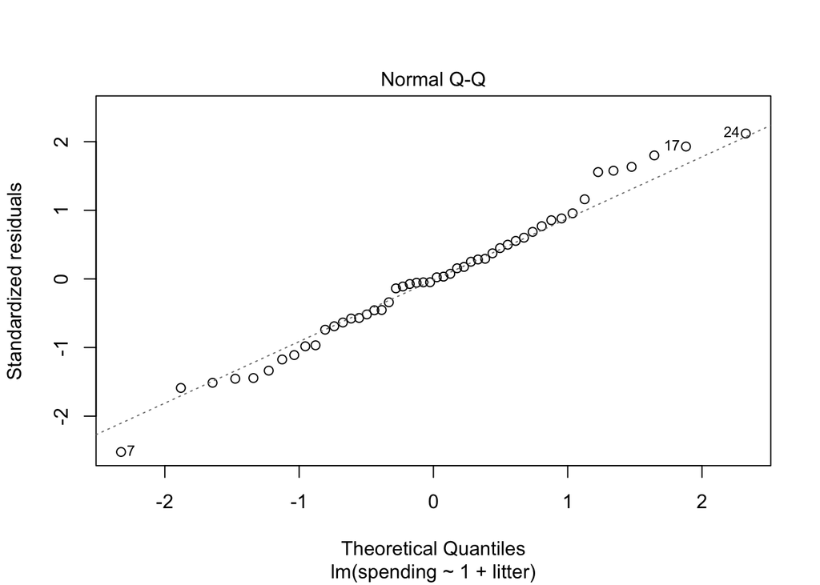

```r
plot(catamaran_lm, which=2)
```

> I would say the top-right is minimally concerning, but overall there is nothing typically unsual from the Q-Q plot and hence looks reasonable.

Once you’ve verified that the residuals look reasonable, and hence our normality assumptions are defensible, construct a 95% confidence interval for the coefficient of `litter` in our model.

```r
catInt = confint(catamaran_lm, level=0.95)
catInt['litter',]
```

```
##    2.5 %   97.5 %
## 1.342085 1.851083
```

Based on this confidence interval, should we accept or reject the null hypothesis that $\beta_1=0$ at level $\alpha=0.05$?

Based on the confidence interval, we should reject the null hypothesis that $\beta_1=0$ at level $\alpha=0.05$ since the 95% interval does not include 0.

Finally, verify your answer by looking at the `summary` output of your model and check that the coefficient is or is not statistically significantly different from zero.

```r
summary(catamaran_lm)
```

```
##
## Call:
## lm(formula = spending ~ 1 + litter, data = catamaran)
##
## Residuals:
##     Min      1Q  Median      3Q     Max
## -32.405  -8.080  -0.167   7.658  27.083
##
## Coefficients:
##             Estimate Std. Error t value Pr(>|t|)
## (Intercept)  44.3555    11.3027   3.924 0.000277 ***
## litter        1.5966     0.1266  12.614  < 2e-16 ***
## ---
## Signif. codes:  0 '***' 0.001 '**' 0.01 '*' 0.05 '.' 0.1 ' ' 1
##
## Residual standard error: 13.14 on 48 degrees of freedom
## Multiple R-squared:  0.7682, Adjusted R-squared:  0.7634
## F-statistic: 159.1 on 1 and 48 DF,  p-value: < 2.2e-16
```

> We can verify our answer by looking at the summary output. The output shows that it is highly unlikely that our estimate is produced by chance and the p-value is extrememly small with a value of approximately 2e-16.

## 2) Understanding the effect of noise

This problem, loosely based on Problem 13 in Chapter 3 of [ISLR](https://www.statlearning.com/), will help to give you an intuition to the role of sample size (i.e., number of observations $n$) and noise level (as captured by the variance $\sigma^2$ of the noise terms $\epsilon_i$).

### Part a) generating linear data

Write a function `generate_linear_data` that takes two arguments: `n` and `sigma2`, in that order, and does the following:

1. Use the `rnorm()` function to create a vector `x`, containing `n` independent observations drawn from a normal distribution with mean $0$ and variance $1$. This will represent our vector of predictors.
2. Use the `rnorm()` function to create a vector, `eps`, containing `n` independent observations drawn from a normal distribution with mean $0$ and variance `sigma2`. These will correspond to the errors in our observed responses.
3. Using `x` and `eps`, construct a vector `y` according to the model
   $$Y = -1 + 0.5X + \epsilon,$$

where $X$ corresponds to entries in our vector `x` and $\epsilon$ corresponds to entries in our vector `eps`.

4. Create a data frame with two columns, `predictors` and `responses` whose entries correspond to the vectors `x` and `y`, respectively. Return this data frame.

You do not need to perform any error checking in this function. You may assume that `n` is a positive integer and `eps` is a positive numeric.

Before writing code, let’s **check your understanding:** What is the length of the vector `y`? What are the values of the intercept $\beta_0$ and slope $\beta_1$ in this linear model?

The length of the vector ‘y’ should be ‘n’, and the intercept $\beta_0$ should be -1 and slope $\beta_1$ should be 0.5. ***

```r
generate_linear_data = function( n, sigma2 ) {
  x = rnorm(n, mean = 0, sd = 1)
  eps = rnorm(n, mean = 0, sd = sqrt(sigma2))

  y = -1 + (0.5*x) + eps

  predictors = x
  responses = y
  linear_data = data.frame(predictors, responses)
  return(linear_data)
}
```

### Part b) Plotting data

Use your function from Part (a) to generate 100 samples from the model
$$Y = -1 + 0.5X + \epsilon,$$

with `sigma2` set to $0.25$ and create a scatterplot of that data, showing the responses $Y$ as a function of $X$. You may use either `ggplot2` or R’s built-in plotting utilities.

Examine the point cloud and discuss: Does the data look approximately linear? Does the slope look about right? What about the intercept? **Note:** You **do not** need to fit a model, yet! Just inspect the data!

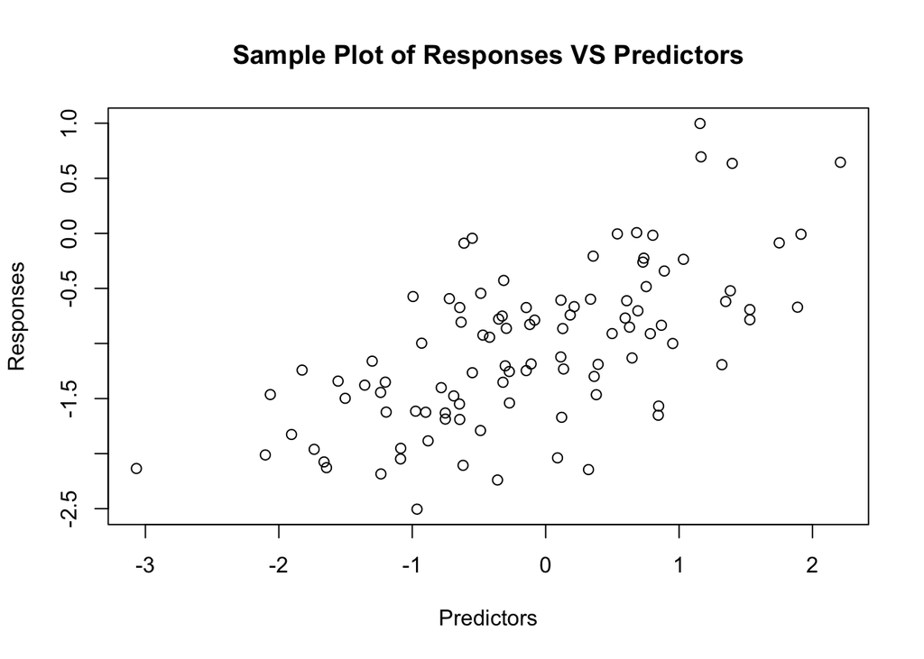

```r
sampleData = generate_linear_data(100, 0.25)

plot(sampleData, main = "Sample Plot of Responses VS Predictors", xlab = "Predictors", ylab = "Responses")
```

Data data does look approximately linear, with responses increasing as predictors increasing. Although different for each run, just by inspection, the slope also appears to be approximately 0.5 and the intercept is also approximately -1.

### Part c) the effect of noise

Now, generate 100 data points again, as in part (b), but increase the noise level (i.e., the variance of the observation errors $\epsilon$) to $1$. That is, set `sigma2` to `1`. Plot the data again, and compare to the previous plot. What do you observe?

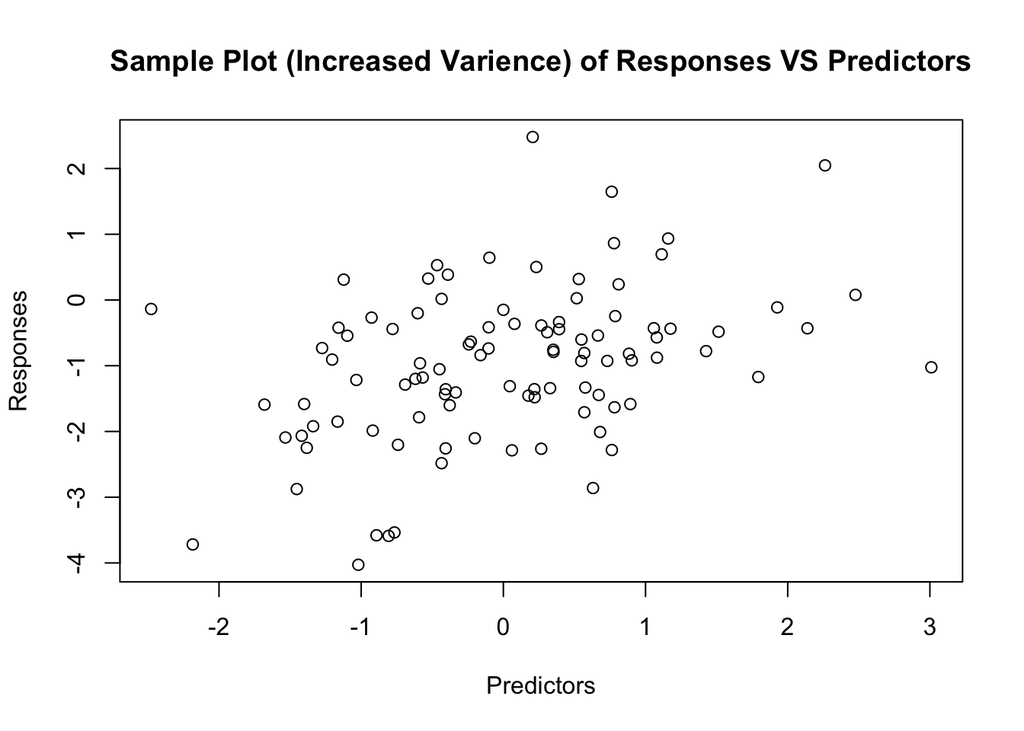

```r
moreNoise = generate_linear_data(100, 1)

plot(moreNoise, main = "Sample Plot (Increased Varience) of Responses VS Predictors", xlab = "Predictors", ylab = "Responses")
```

The data still looks somewhat linear, however there is much more noise in the data, making it slightly harder to identify this linearity. It is now much more difficult to calculate the slope and intercept because of this noise.

Now, try decreasing the noise level (i.e., the variance of the $\epsilon$ terms), down to $\sigma^2 = 0.1$ and create one more plot, again with $n=100$ data points. What do you observe?

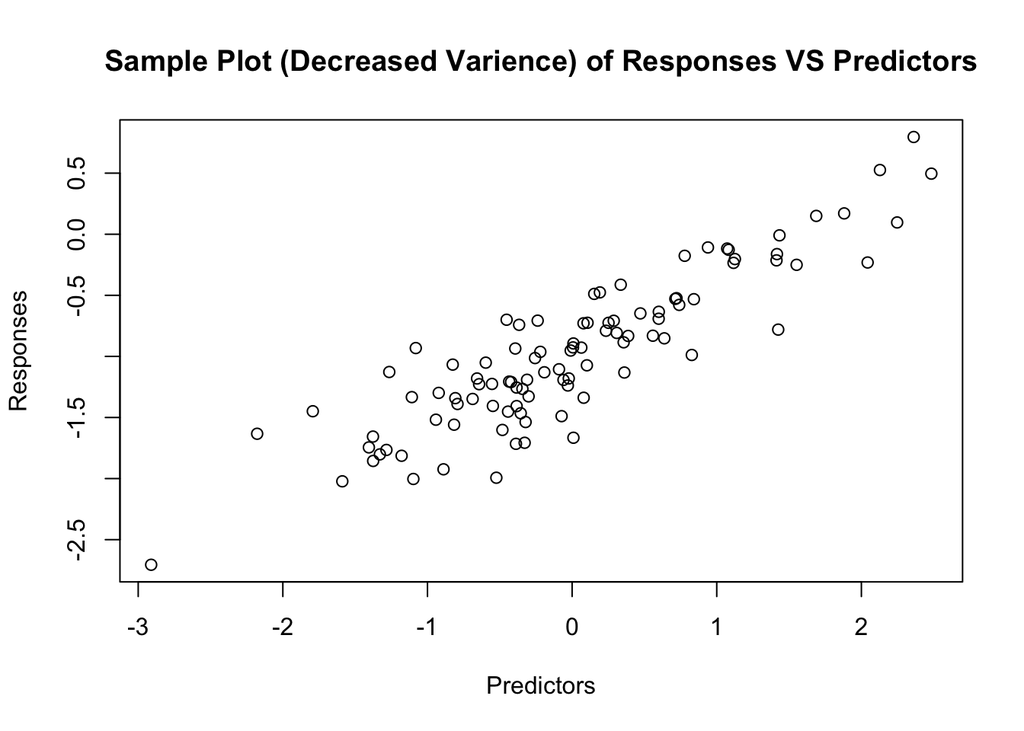

```r
lessNoise = generate_linear_data(100, 0.1)

plot(lessNoise, main = "Sample Plot (Decreased Varience) of Responses VS Predictors", xlab = "Predictors", ylab = "Responses")
```

As expected, decreasing the variance makes the trend a lot easier to distinguish, and the plot looks more like the plot form part b than part c. With this trend, it is more easier to inspect the slope of 0.5 and intercept of -1.

### Part d) estimating from synthetic data

Now, let’s investigate how the amount of noise (i.e., the error term variance $\sigma^2$) influences our estimation of the slope $\beta_1$. Hopefully in your plots above you noticed that when the variance $\sigma^2$ is larger, the linear trend in the data is “harder to see”. Perhaps unsurprisingly, but still interestingly, this translates directly into difficulty in estimating the coefficients. When there is more noise in our observations, our estimation of the coefficients suffers.

Let’s investigate this with a simulation. This part of the problem will have you write code to run a single experiment wherein we generate data and try to estimate the slope $\beta_1$. In Part (e) below, we’ll use this single-trial code to run a Monte Carlo simulation that estimates the variance of our estimate $\hat{\beta}_1$. We’ll be able to see how the variance of our estimate (i.e., how close we are on average to the true $\beta_1$) changes as the noise $\sigma^2$ changes.

Write a function `generate_and_estimate` that takes two arguments: a sample size `n` and a variance term `sigma2`, and does the following:

1. Use `generate_linear_data` to generate a collection of `n` observations from a linear model
   $$Y = -1 + 0.5X + \epsilon,$$
   where the noise term $\epsilon$ is normal with variance `sigma2`.
2. Pass this data into `lm()` to fit a model predicting the column `responses` from the column `predictors` and an intercept term.
3. Extract the estimate of the slope from the resulting fitted model object (hint: look at the `coefficients` attribute of the model object or use the function `coef()`). Call this `beta1hat`. **Hint:** don’t forget to use `unname()` to remove the “names” of the coefficients extracted from the model object.
4. Return `beta1hat`.

```r
generate_and_estimate = function( n, sigma2 ) {
  observations = generate_linear_data(n, sigma2)
  model = lm(responses ~ 1 + predictors, data = observations)
  beta1hat = unname(coef(model)[2])
  return(beta1hat)
}
```

### Part e) estimating variance of an estimator

Now, let’s write code compute a Monte Carlo estimate of the variance of our estimator $\hat{\beta}_1$. Note that this variance is a good way to measure the (average) squared error of our estimator. When this variance is large, it means that our estimate of $\beta_1$ is more uncertain, as we expect to be farther from the true value of $\beta_1$ more often, on average.

Write a function `estimate_beta1hat_variance` that takes three arguments: a number of observations `n`, a variance `sigma2` and a number of Monte Carlo replicates `M`, and does the following:

1. Use `generate_and_estimate` to generate a collection of `n` observations from a linear model
   $$Y = -1 + 0.5X + \epsilon,$$
   where the noise term $\epsilon$ is normal with variance `sigma2`, and estimate $\beta_1$. Call the resulting estimate `beta1hat`.
2. Perform step 1 a total of `M` times, recording the resulting `beta1hat` each time in a vector. That is, perform `M` Monte Carlo iterations of the experiment wherein we generate random data and estimate the slope $\beta_1 = 0.5$, keeping track of our estimate in each Monte Carlo replicate.
3. Compute and return the variance of our `M` random `beta1hat` replicates. This is a Monte Carlo estimate of the variance of our estimate $\hat{\beta}_1$. You may use either the corrected or uncorrected sample variance in this calculation.

```r
estimate_beta1hat_variance = function( n, sigma2, M ) {
  replicates <- rep(NA,M)
  for (i in 1:M) {
    replicates[i] = generate_and_estimate(n, sigma2)
  }

  estimate = var(replicates)
  return(estimate)
}
```

### Part f) effect of noise on estimation accuracy

Use your function from Part (e) to create a plot of the variance (as estimated from 1000 Monte Carlo iterates) of the estimator $\hat{\beta}_1$, as a function of $\sigma^2$, when $n=100$. Use values for $\sigma^2$ ranging from $0.25$ to $4$, inclusive, in increments of $0.25$. You may use either `ggplot2` or the built-in R plotting functions.

**Note:** this simulation make take a few minutes to run, since for each value of $\sigma^2$, we must perform $M=1000$ simulations, and each simulation requires fitting linear regression, which is not free!

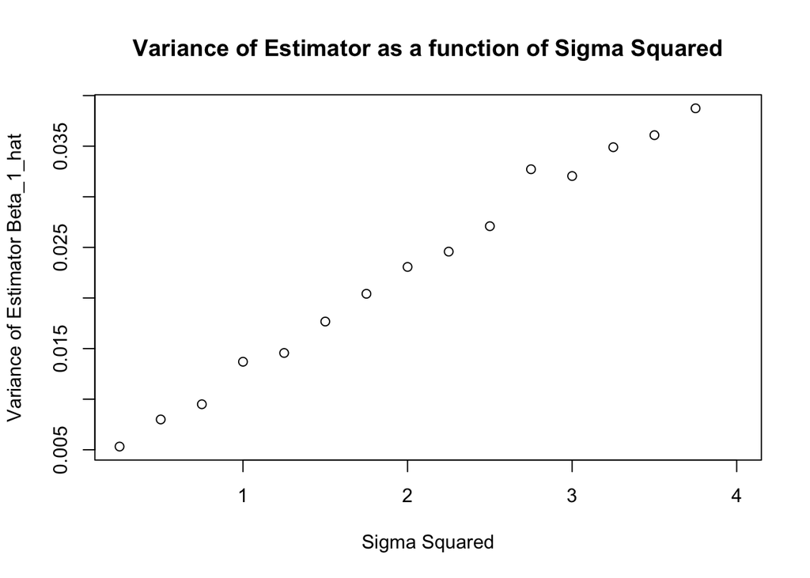

```r
sig2 = seq(0.25, 4, 0.25)
estimates = rep(NA, length(sig2))
i = 0

for (sig in sig2) {
  estimates[i] = estimate_beta1hat_variance(100, sig, 1000)
  i = i + 1
}

plot(sig2, estimates, main = "Variance of Estimator as a function of Sigma Squared", xlab = "Sigma Squared", ylab = "Variance of Estimator Beta_1_hat")
```

Based on your plot, how does it look like the variance of our estimator $\hat{\beta}_1$ behaves as a function of the observation error variance $\sigma^2$?

If you look up the variance of $\hat{\beta}_1$ in a mathematical statistics textbook, you will find that
$$\operatorname{Var} \hat{\beta}_1
=
\frac{ \sigma^2 }{ \sum_{i=1}^n (x_i - \bar{x})^2 }.$$

Does this agree with your plot above?

Before looking at the equation, the plot shos that the variance of our estimator is associated linearly with sigma squared. Looking at the equation, it is indeed true that the varience of the estimated beta_1_hat is a linear function of sigma squared. This is strictly shown in our plot where the variance of the estimator increases linearly as sigma squared increases as well.

## 3) More regression with `mtcars`

In lecture, we worked briefly with the `mtcars` data set. Let’s get more regression practice by working with it some more.

### a) background

Run `?mtcars` in the console (please **do not** add it to this `Rmd` file) and briefly read the help page. Specifically, take note of the following:

1. What is the source of this data?
2. What is this data set measuring (i.e., what was the response variable in the original study, at least based on the brief description in the R documentation)?
3. What predictors are available and what do they mean?
1. The data was extracted from the 1974 Motor Trend US magazine.
2. Data data set measures miles per gallon as the response variable.
3. There are a total of 10 predictors available as listed below:
- mpg = Miles/(US) gallon
- cyl = Number of cylinders
- disp = Displacement (cu.in.)
- hp = Gross horsepower
- drat = Rear axle ratio
- wt = Weight (1000 lbs)
- qsec = 1/4 mile time
- vs = Engine (0 = V-shaped, 1 = straight)
- am = Transmission (0 = automatic, 1 = manual)
- gear = Number of forward gears
- carb = Number of carburetors

You may want to also run `head(mtcars, 10)` or `View(mtcars)` to inspect the data frame briefly before moving on.

### b) Fitting a model

Use `lm` to run a regression of `mpg` on a few predictors in the data frame (choose two or three that you think would make a good model– don’t use all ten; we’ll talk about why in later lectures). Make sure to include `data = mtcars` as a keyword argument to `lm` so that R knows what data frame to use.

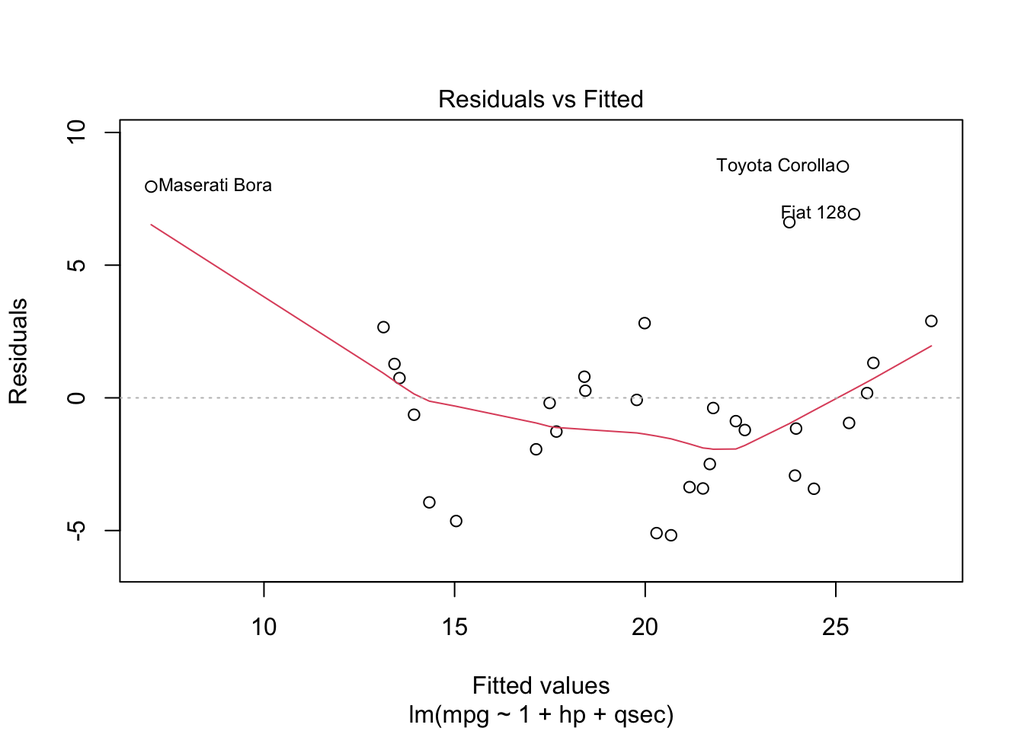

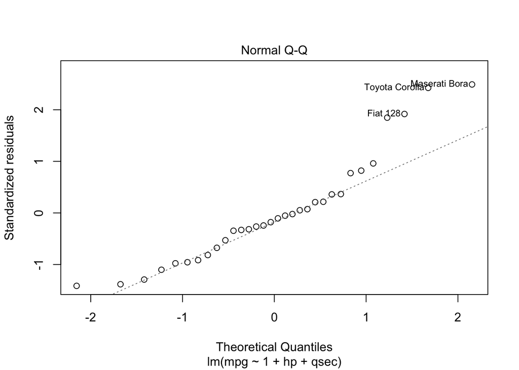

```r
lm.mtcars = lm(mpg ~ 1 + hp + qsec, data = mtcars)

plot(lm.mtcars,ask=F,which=1:2)
```

Briefly inspect the residuals plot by running `plot(lm.mtcars,ask=F,which=1:2)`. What do you observe, and what does it mean?

We see that the right tail is a lot longer than expected. This means that that the variability of the residuals changes as the values of ‘hp’ and ‘qsec’ also change. Thus, we should be a bit careful with how much credence we give to any quantities that depend on our normality assumption. We should also bear in the back of our minds that perhaps our normality assumptions aren’t exactly true.

### c) Interpreting the model

View the summary of your model by uncommenting and running the code below.

```r
# summary(lm.mtcars)
```

Pick one of your predictors and give an interpretation of the estimate and standard error for its coefficient. Be careful in your wording of the interpretation.

Which coefficients are statistically significantly different from zero? How do you know?

### d) Interpreting residuals

What is the Residual Standard Error (RSE) for this model? How many degrees of freedom does it have?

What is the value of $R^2$ for this model? (**Hint:** look at the output of `summary`) Give an interpretation of this value.

### e) Adjusted $R^2$

Briefly read about the adjusted $R^2$ [here](https://www.statisticshowto.com/probability-and-statistics/statistics-definitions/adjusted-r2/). What is the adjusted $R^2$ of this model and how does this differ from the usual $R^2$ value? (**Hint:** again, look at the output of `summary`).

### f) CIs for coefficients

Read the documentation for the `confint` function, and use it to generate $95\%$ confidence intervals for the coefficients of your model. Give an interpretation of these confidence intervals.

```r
confint(lm.mtcars, level = 0.95)
```

```
##                  2.5 %      97.5 %
## (Intercept) 25.6148939 71.03251639
## hp          -0.1130888 -0.05609724
## qsec        -1.9799295  0.20677024
```

We are 95% confident that the true coefficients lie between the each specified interval. It is meaningful to note that the interval for qsec includes zero, which is in line with the fact that we are not able to reject the null hypothesis that qsec is statistically close to zero. In contrast, we see that the intervals for the intercept and hp does not include zero, which also is in line with the fact that we are able to reject the null hypothesis that both coefficients are statistically close to zero.

## 4) the `cats` data set

The `cats` data set, included in the `MASS` library, contains data recorded from 144 cats. Each row of the data set contains the body weight (`Bwt`, in kgs), heart weight (`Hwt`, in grams) and the sex (`Sex`, levels `'F'` and `'M'`) for one of the cats in the data set.

**Part a: plotting the data**

Create a scatter plot showing heart weight on the y-axis and body weight on the x-axis. Ignore the `Sex` variable in this plot.

```r
library(MASS)
head(cats)
```

```
##   Sex Bwt Hwt
## 1   F 2.0 7.0
## 2   F 2.0 7.4
## 3   F 2.0 9.5
## 4   F 2.1 7.2
## 5   F 2.1 7.3
## 6   F 2.1 7.6
```

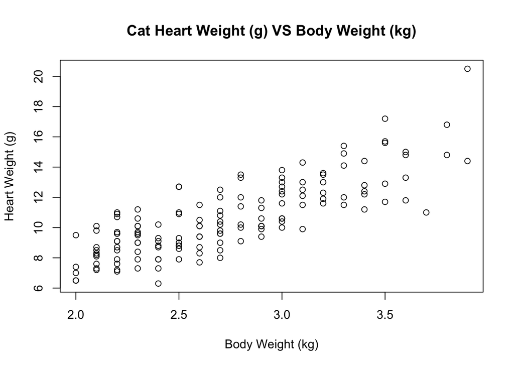

```r
plot(cats$Bwt, cats$Hwt, main = "Cat Heart Weight (g) VS Body Weight (kg)", xlab = "Body Weight (kg)", ylab = "Heart Weight (g)")
```

Briefly describe what you see. Is there a clear trend in the data?

> I would say that there is a positive linear trend between body weight and heart weight.As Heart weight increases, body weight also seem to increase, whichi suggests the positive association. However I would stil say that there is some level of varariability for the body weight for each heary weight value. In conclusion, I would say there is a ‘clear’ trend of linearity but still I believe we should note the variance of the body weight data.

**Part b: fitting a linear model**

Fit a linear regression model to predict cat heart weight from cat body weight (and using an intercept term, of course).

```r
lm.cats = lm(Hwt ~ 1 + Bwt, data = cats)
```

Examine the coefficients of your fitted model. What is the coefficient for the `Bwt` variable? Interpret this coefficient– a unit change in body weight yields how much change in heart weight?

```r
lm.cats$coefficients
```

```
## (Intercept)         Bwt
##  -0.3566624   4.0340627
```

The model gives us 4.04 for the body weight coefficient. This means that a unit change in body weight yields approximately 4.04 increase in grams for the heart rate.

**Part c: back to plotting**

Create the same plot from Part a above, but this time color the points in the scatter plot according to the `Sex` variable. You may use either `ggplot2` or the built-in R plotting tools, though I would recommend the former, for this.

You should see a clear pattern. Describe it. A sentence or two is fine here.

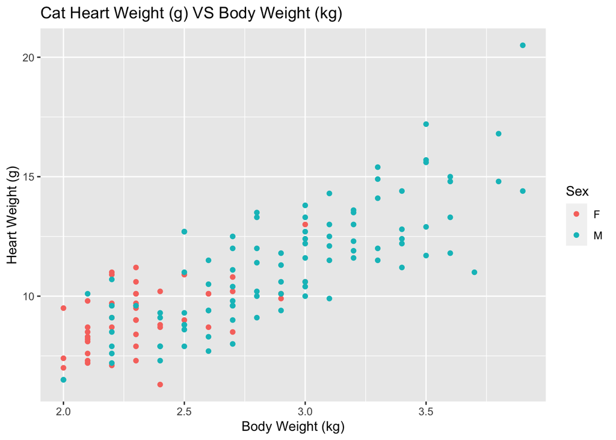

```r
library(ggplot2)

ggplot(cats, aes(x = Bwt, y = Hwt, color = Sex)) + geom_point() + xlab("Body Weight (kg)") + ylab("Heart Weight (g)") + ggtitle("Cat Heart Weight (g) VS Body Weight (kg)")
```

We see the same plot from Part a but with clear distinguishment for the sexes of the cats. It is clear that as we look at increased body weight (and also heart weight), we see that the the majority of the points become male cats instead. In contrast, the majority of the bottom-left (lower body weight and heart weight) are female cats.

**Part d: adding `Sex` and an interaction**

From looking at the data, it should be clear that the `Sex` variable has explanatory power in predicting heart weight, but it is also very correlated with body weight.

Fit a new linear regression model, still predicting heart weight, but this time including both body weight and sex as predictors *and* an interaction term between body weight and sex. Take note of how R assigns `Sex` a dummy encoding.

```r
lm_catSex = lm(Hwt ~ 1 + Bwt + Sex + Bwt:Sex, data = cats)
```

Examine the outputs of your model. In particular, note the coefficients of `Sex` and the interaction between `Bwt` and `Sex`. Are both of these coefficients statistically significantly different from zero? How do you interpret the interaction term?